# Average Daily Temperatures

This article presents the “Unbraided Ribbon Problem” in which `geom_ribbon()` incorrectly fills the area between two alternating lines with two different colors. To fix the problem, we use `geom_braid()` from ggbraid with `method = 'line'`.

Let’s compare the temperatures of two cities in the United States: New York, New York and San Francisco, California.

## Getting Started

ggbraid provides a data frame called `temps`, with daily average temperatures of New York and San Francisco in 2021 as recorded by the US National Weather Service (NWS) at [weather.gov](https://www.weather.gov/).[^1]

```r
library(ggplot2)
library(ggbraid)
library(dplyr)
library(tidyr)

data(temps)

temps
```

```
#> # A tibble: 730 × 3
#>    city     date         avg
#>    <chr>    <date>     <dbl>
#>  1 New York 2021-01-01  36.5
#>  2 New York 2021-01-02  43.5
#>  3 New York 2021-01-03  36
#>  4 New York 2021-01-04  39
#>  5 New York 2021-01-05  39
#>  6 New York 2021-01-06  37.5
#>  7 New York 2021-01-07  35.5
#>  8 New York 2021-01-08  32
#>  9 New York 2021-01-09  30.5
#> 10 New York 2021-01-10  35
#> # … with 720 more rows
```

`city` is `New York` or `San Francisco`, `date` is a calendar date in the `YYYY-MM-DD` format, and `avg` is the average temperature recorded in degrees Fahrenheit (°F) and rounded to the nearest half degree.[^2]

What do the daily average temperatures look like?

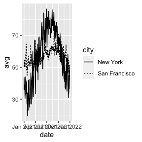

```r
ggplot(temps) +
    geom_line(aes(x = date, y = avg, linetype = city))
```

We see much higher variability in temperatures in New York compared with San Francisco. This makes sense — New York is in the Northeastern US and experiences hot, humid summers and cold, occassionally snowy winters. San Francisco is on the West Coast and its Mediterranean climate means its temperature does not change much season to season.

Before we proceed further, let’s clean up the plot a bit and assign it to a variable `p` so we can reuse it throughout the article.

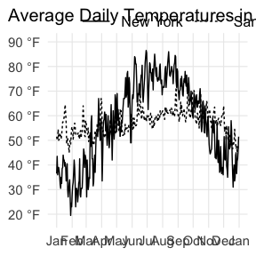

```r
p <- ggplot() +
  geom_line(aes(x = date, y = avg, linetype = city), data = temps) +
  scale_x_date(date_breaks = "1 month", date_labels = "%b") +
  scale_y_continuous(
    breaks = seq(20, 90, by = 10),
    labels = function(x, ...) format(paste(x, "°F"), ...),
    limits = c(18, 90)
  ) +
  guides(fill = "none") +
  labs(
    title = "Average Daily Temperatures in 2021",
    linetype = NULL,
    y = NULL,
    x = NULL
  ) +
  theme_minimal(base_size = 14) +
  theme(
    plot.title = element_text(size = 15),
    plot.title.position = "plot",
    legend.position = c(0.75, 1.06),
    legend.direction = "horizontal",
    legend.key.size = unit(2, "line"),
    legend.text = element_text(size = 12),
    panel.grid.major.x = element_line(size = 0.4),
    panel.grid.major.y = element_line(size = 0.4),
    panel.grid.minor.x = element_blank(),
    panel.grid.minor.y = element_blank()
  )

p
```

Much better.

## Fun with Ribbons

Let’s fill the area between the two lines. We can do so with `geom_ribbon()` from `ggplot2`.

`geom_ribbon()` requires three aesthetics: `x`, `ymin`, and `ymax`. We can map `date` to `x` as we did in `geom_line()`. However, we’ll need to transform `temps` to create new variables that we can map to `ymin` and `ymax`.

We can pivot `temps` with `pivot_wider()` from the `tidyr` package, taking column names from `city` and values from `avg`. Call the new data frame `temps_wide`.

```r
temps_wide <- temps %>%
  pivot_wider(names_from = city, values_from = avg) %>%
  rename(ny = `New York`, sf = `San Francisco`)

temps_wide
```

```
#> # A tibble: 365 × 3
#>    date          ny    sf
#>    <date>     <dbl> <dbl>
#>  1 2021-01-01  36.5  51.5
#>  2 2021-01-02  43.5  50
#>  3 2021-01-03  36    50.5
#>  4 2021-01-04  39    54.5
#>  5 2021-01-05  39    50
#>  6 2021-01-06  37.5  50.5
#>  7 2021-01-07  35.5  53
#>  8 2021-01-08  32    52.5
#>  9 2021-01-09  30.5  52
#> 10 2021-01-10  35    50.5
#> # … with 355 more rows
```

Now we can add a new layer to `p` with `geom_ribbon()` using `temps_wide`. Map `date` to `x`, `ny` to `ymin`, and `sf` to `ymax`.[^3] Finally, add some transparency with `alpha = 0.3`.

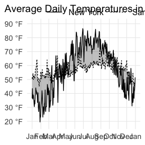

```r
p +
  geom_ribbon(
    aes(x = date, ymin = ny, ymax = sf),
    data = temps_wide,
    alpha = 0.3
  )
```

Great! Using `geom_ribbon()` we’ve added a light grey ribbon that runs between the two lines.

On second thought… what if we used two colors for the ribbon? We could have one color when New York is hotter than San Francisco and another color when New York is colder than San Francisco.

This shouldn’t be hard to do. Map `sf > ny` to `fill` in `geom_ribbon()` and…

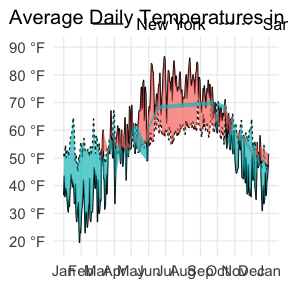

```r
p +
  geom_ribbon(
    aes(x = date, ymin = ny, ymax = sf, fill = sf > ny),
    data = temps_wide,
    alpha = 0.7
  )
```

Chaos. What happened?

## The Unbraided Ribbon Problem

Is this a bug in `geom_ribbon()`?

No, it’s not a bug. The problem is that **we haven’t dealt with line intersections properly.**

For example, consider rows 80-82 from `temps_wide`:

| date | ny | sf |
| --- | --- | --- |
| 2021-03-21 | 52.5 | 52.0 |
| 2021-03-22 | 52.0 | 52.0 |
| 2021-03-23 | 54.5 | 56.5 |

After we have pass `temps_wide` to `geom_ribbon()` and map `date` to `x`, `ny` to `ymin`, `sf` to `ymax`, and `sf > ny` to `fill`, we get the following:

| x | ymin | ymax | fill |
| --- | --- | --- | --- |
| 18707 | 52.5 | 52.0 | FALSE |
| 18708 | 52.0 | 52.0 | FALSE |
| 18709 | 54.5 | 56.5 | TRUE |

(`x` is the integer representation of `date`, the number of days since January 1, 1970, the “Unix epoch”)

Ok, note the middle row. `ymin` and `ymax` are equal here, so this is a point where the two lines intersect. It turns out that `geom_ribbon()` requires two rows for every line intersection, one row where `fill` is `FALSE` and another row where `fill` is `TRUE`.

So we must insert a new row in the data, yielding the following:

| x | ymin | ymax | fill |
| --- | --- | --- | --- |
| 18707 | 52.5 | 52.0 | FALSE |
| 18708 | 52.0 | 52.0 | FALSE |
| **18708** | **52.0** | **52.0** | **TRUE** |
| 18709 | 54.5 | 56.5 | TRUE |

We call this process *braiding*.

**We need to braid the ribbon where the lines intersect.**

And the intersection described here is not the only type that requires braiding.

There are instances where the two lines intersect *between* two rows in the data. In these cases, we must use a mathematical formula to determine the exact point at which the lines intersect and braid the ribbon accordingly. There are also instances where both lines are vertical at the same `x`, an uncommon situation but one that produces an infinite number of intersection points and requires braiding to fix.

## Braiding with ggbraid

The functions in ggbraid take care of all the braiding for you. Simply replace `geom_ribbon()` with `geom_braid()`.

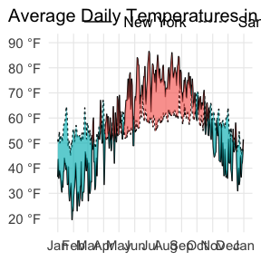

```r
p +
  geom_braid(
    aes(x = date, ymin = ny, ymax = sf, fill = sf > ny),
    data = temps_wide,
    alpha = 0.7
  )
```

There we go!

`geom_braid()` takes the data provided, performs the necessary braiding operations on it with `stat_braid()`, and passes the result to `geom_ribbon()` for drawing. If we’d like, we can still use `geom_ribbon()` and set `stat = 'braid'`.

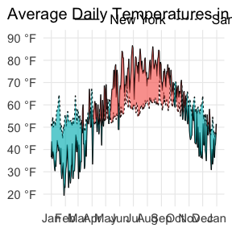

```r
p +
  geom_ribbon(
    aes(x = date, ymin = ny, ymax = sf, fill = sf > ny),
    data = temps_wide,
    stat = "braid",
    method = "line",
    alpha = 0.7
  )
```

Finally, it may be helpful to label the ribbon colors so it’s clear what they represent. This can happen in a legend (which we’ve turned off with the `guides(fill = "none")` layer in `p`). Another possibility is to provide text annotations on the plot.

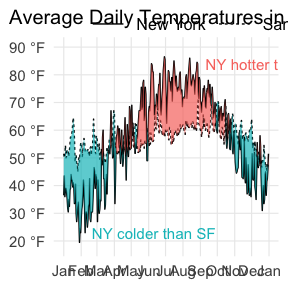

```r
hues <- scales::hue_pal()(2)  # ggplot2 default color palette

p +
  geom_braid(
    aes(x = date, ymin = ny, ymax = sf, fill = sf > ny),
    data = temps_wide,
    method = "line",
    alpha = 0.7
  ) +
  annotate("text", x = as.Date("2021-09-10"), y = 84, size = 4, label = "NY hotter than SF", hjust = 0, color = hues[1]) +
  annotate("text", x = as.Date("2021-02-20"), y = 23, size = 4, label = "NY colder than SF", hjust = 0, color = hues[2])
```

[^1]: It is difficult to pull data from the NWS. It does not provide the data via an API and the data it returns through its point-and-click interface isn’t in plain text format! To make matters worse, you can only retrieve data from a city one month at a time. For San Francisco, visit weather.gov/wrh/climate?wfo=mtr and choose “San Francisco City, CA”, “Daily data for a month”, and a month from 2021; for New York, visit weather.gov/wrh/climate?wfo=okx and choose “NY-Central Park Area”, “Daily data for a month”, and a month from 2021. Copy and paste the data into spreadsheet software for further processing.
[^2]: For those who use degrees Celsius: 0°C is 32°F, 10°C is 50°F, 20°C is 68°F, and 30°C is 86°F.
[^3]: Why not the other way around, with `sf` to `ymin` and `ny` to `ymax`? That’s fine too because the lines alternate over/under one another.